# Disaggregated Data Exploration and ICC Computation

## Restructure the Data

The current dataset is very long – each row is a single response to a single question. To better facilitate some of the upcoming analyses, we’ll restructure into a wider format. Here, each row will contain all of the responses from one participant about one target. Since each participant rated a set of 5 targets as well as themselves (for demographic items), each participant will have a total of 6 rows for each kind of stimuli (note that participants who completed several different surveys (e.g., profiles and followers) are still included, so they can have up to 18 rows).

Make the dataset wide, dropping the variables that identify the question numbers (they’re redundant with the labels but less informative):

```r
df_wide<-dcast(df %>% select(-c(question, orig_quest_num)),
                pID + target_user + stim + study + ...
               ~qlabel,
               value.var="value")
df_wide %>% arrange(pID, target_user) %>% head()
```

|  | pID | target_user | stim | study | sam | df | start_date | end_date | finished | consent | sample | same_target | duration | survey_sd | attempt | stim_attempt | mult_attempts | mult_stim_attempts | actimag | adviceGoodImpression | age | arrogant | askNotes | assertive | attractive | buySomethingOnline | casualSocial | centerattn | cold | … |
| --- | --- | --- | --- | --- | --- | --- | --- | --- | --- | --- | --- | --- | --- | --- | --- | --- | --- | --- | --- | --- | --- | --- | --- | --- | --- | --- | --- | --- | --- | --- |
| 1 | 201 | 92 | profile | 1 | 1 | 1 | 2013-10-12 16:25:12 | 2013-10-12 16:46:35 | 1 | 1 | hsp | 0 | 21.38333 | 3.742554 | 1 | 1 | 0 | 0 | 3 | NA | 19 | 3 | NA | 4 | 3 | NA | NA | 4 | 4 | … |
| 2 | 201 | 93 | profile | 1 | 1 | 1 | 2013-10-12 16:25:12 | 2013-10-12 16:46:35 | 1 | 1 | hsp | 0 | 21.38333 | 3.742554 | 1 | 1 | 0 | 0 | 2 | NA | 17 | 3 | NA | 3 | 2 | NA | NA | 3 | 3 | … |
| 3 | 201 | 94 | profile | 1 | 1 | 1 | 2013-10-12 16:25:12 | 2013-10-12 16:46:35 | 1 | 1 | hsp | 0 | 21.38333 | 3.742554 | 1 | 1 | 0 | 0 | 2 | NA | 21 | 4 | NA | 4 | 2 | NA | NA | 5 | 4 | … |
| 4 | 201 | 95 | profile | 1 | 1 | 1 | 2013-10-12 16:25:12 | 2013-10-12 16:46:35 | 1 | 1 | hsp | 0 | 21.38333 | 3.742554 | 1 | 1 | 0 | 0 | 3 | NA | 19 | 3 | NA | 2 | 3 | NA | NA | 3 | 3 | … |
| 5 | 201 | 96 | profile | 1 | 1 | 1 | 2013-10-12 16:25:12 | 2013-10-12 16:46:35 | 1 | 1 | hsp | 0 | 21.38333 | 3.742554 | 1 | 1 | 0 | 0 | 2 | NA | 19 | 4 | NA | 3 | 3 | NA | NA | 3 | 3 | … |
| 6 | 201 | 201 | profile | 1 | 1 | 1 | 2013-10-12 16:25:12 | 2013-10-12 16:46:35 | 1 | 1 | hsp | 0 | 21.38333 | 3.742554 | 1 | 1 | 0 | 0 | NA | NA | NA | NA | NA | NA | NA | NA | NA | NA | NA | … |

## Scoring Big 5 Scales

Before looking too closely, we’ll start by reverse-coding and scoring the B5 scales (from BFI-10). Note that we did ask a handful of extraversion-related questions, but will only score the two that come from the 10-item version of the scale.

```r
df_wide <- df_wide %>%
        mutate(cold_r = 6-cold,
                   reserved_r = 6 - reserved,
                   lazy_r = 6 - lazy,
                   relaxed_r = 6 - relaxed,
                   fewartint_r = 6 - fewartint) %>%
        mutate(ext = (outgoing + cold_r)/2,
               agr = (trusting+reserved_r)/2,
               con = (thorough + lazy_r)/2,
               neu = (nervous + relaxed_r)/2,
               ope = (actimag + fewartint_r)/2)
```

Convert back to long:

```r
df2<- df_wide %>% gather(qlabel, # name of the new key variable
                         value, # name of the new value variable
                         c(actimag:introduceFriend, lazy:ope), # variables to make long; all of them except know
                         na.rm = T) %>% # drop rows where value is missing
        arrange(pID, target_user)
(df2)
```

| pID | target_user | stim | study | sam | df | start_date | end_date | finished | consent | sample | same_target | duration | survey_sd | attempt | stim_attempt | mult_attempts | mult_stim_attempts | know | qlabel | value |
| --- | --- | --- | --- | --- | --- | --- | --- | --- | --- | --- | --- | --- | --- | --- | --- | --- | --- | --- | --- | --- |
| 201 | 92 | profile | 1 | 1 | 1 | 2013-10-12 16:25:12 | 2013-10-12 16:46:35 | 1 | 1 | hsp | 0 | 21.38333 | 3.742554 | 1 | 1 | 0 | 0 | 2 | actimag | 3.0 |
| 201 | 92 | profile | 1 | 1 | 1 | 2013-10-12 16:25:12 | 2013-10-12 16:46:35 | 1 | 1 | hsp | 0 | 21.38333 | 3.742554 | 1 | 1 | 0 | 0 | 2 | age | 19.0 |
| 201 | 92 | profile | 1 | 1 | 1 | 2013-10-12 16:25:12 | 2013-10-12 16:46:35 | 1 | 1 | hsp | 0 | 21.38333 | 3.742554 | 1 | 1 | 0 | 0 | 2 | arrogant | 3.0 |
| 201 | 92 | profile | 1 | 1 | 1 | 2013-10-12 16:25:12 | 2013-10-12 16:46:35 | 1 | 1 | hsp | 0 | 21.38333 | 3.742554 | 1 | 1 | 0 | 0 | 2 | assertive | 4.0 |
| 201 | 92 | profile | 1 | 1 | 1 | 2013-10-12 16:25:12 | 2013-10-12 16:46:35 | 1 | 1 | hsp | 0 | 21.38333 | 3.742554 | 1 | 1 | 0 | 0 | 2 | attractive | 3.0 |
| 201 | 92 | profile | 1 | 1 | 1 | 2013-10-12 16:25:12 | 2013-10-12 16:46:35 | 1 | 1 | hsp | 0 | 21.38333 | 3.742554 | 1 | 1 | 0 | 0 | 2 | centerattn | 4.0 |
| 201 | 92 | profile | 1 | 1 | 1 | 2013-10-12 16:25:12 | 2013-10-12 16:46:35 | 1 | 1 | hsp | 0 | 21.38333 | 3.742554 | 1 | 1 | 0 | 0 | 2 | cold | 4.0 |
| 201 | 92 | profile | 1 | 1 | 1 | 2013-10-12 16:25:12 | 2013-10-12 16:46:35 | 1 | 1 | hsp | 0 | 21.38333 | 3.742554 | 1 | 1 | 0 | 0 | 2 | fewartint | 2.0 |
| 201 | 92 | profile | 1 | 1 | 1 | 2013-10-12 16:25:12 | 2013-10-12 16:46:35 | 1 | 1 | hsp | 0 | 21.38333 | 3.742554 | 1 | 1 | 0 | 0 | 2 | funny | 4.0 |
| 201 | 92 | profile | 1 | 1 | 1 | 2013-10-12 16:25:12 | 2013-10-12 16:46:35 | 1 | 1 | hsp | 0 | 21.38333 | 3.742554 | 1 | 1 | 0 | 0 | 2 | ilike | 3.0 |

[output cut: 990 more lines]

## Pre-Processing Factor Vars

Now that we’re in wide format, it’ll be easier to change some of the less intuitive ways Qualtrics encoded some of the values. We’ll also re-code the categorical variables to give them more meaningful values, and transform some of our character vars to factors so they’re easier to work with. Note that all of the likert responses are 1 (strongly disagree) to 5 (strongly agree), with the exception of SES, which is 1 (low) to 10 (high).

Note that all variables that start with `sub_` are participants’ reports about themselves, and all other variables are participants’ reports about the target. E.g., `sub_age` is the participant’s report of thier own age, and `age` is the participant’s report of how old they think the target is.

Convert to factors:

```r
df_wide <- df_wide %>% mutate(sex = factor(sex),
                              sub_sex = factor(sub_sex),
                              sub_sexOrientation = factor(sub_sexOrientation),
                              race = factor(race),
                              sub_EngFirstLang = factor(sub_EngFirstLang),
                              sub_durationEng = factor(sub_durationEng),
                              sub_socMediaUse = factor(sub_socMediaUse),
                              sub_twitteruse = factor(sub_twitteruse),
                              sample = factor(sample),
                              pID = factor(pID),
                              target_user = factor(target_user),
                              stim = factor(stim),
                              study = factor(study),
                              sub_raceAsian = factor(sub_raceAsian),
                              sub_raceBlk = factor(sub_raceBlk),
                              sub_raceHisp = factor(sub_raceHisp),
                              sub_raceNatAm = factor(sub_raceNatAm),
                              sub_raceOther = factor(sub_raceOther),
                              sub_raceWht = factor(sub_raceWht),
                              know = factor(know)
                              )
```

```r
summary((df_wide$sex))
```

```
   1    2    3 NA's
1351 1776   18 1427
```

```r
summary((df_wide$sub_sex))
```

```
   1    2    3 NA's
 263  497    2 3810
```

```r
summary((df_wide$sub_sexOrientation))
```

```
   1    2    3    4 NA's
   4  122    4    3 4439
```

```r
summary((df_wide$race))
```

```
   1    2    3    4    5    6    7 NA's
 766  119  270   40   33 1831   84 1429
```

```r
summary((df_wide$sub_EngFirstLang))
```

```
   1    2 NA's
 692   70 3810
```

```r
summary((df_wide$sub_durationEng))
```

```
   2    3    4    5    6 NA's
   2    5    5    9  165 4386
```

```r
summary((df_wide$sub_socMediaUse))
```

```
   1    2    3    4    5    6    7 NA's
  26   28    8   20   37  114  527 3812
```

```r
summary((df_wide$sub_twitteruse))
```

```
   1    2    3    4    5    6    7 NA's
 262  100   26   61   50   79  182 3812
```

This will throw an ‘Unknown levels’ warning; it’s fine to ignore.

```r
df_wide <- df_wide %>% mutate(sex = fct_recode(sex,
                                    "male" = "1",
                                    "female" = "2",
                                    "other" = "3"),
                   sub_sex = fct_recode(sub_sex,
                                    "male" = "1",
                                    "female" = "2",
                                    "other" = "3"),
                   sub_sexOrientation = fct_recode(sub_sexOrientation,
                                                   "homosexual" = "1",
                                                   "heterosexual" = "2",
                                                   "bisexual" = "3",
                                                   "other" = "4"),
                   race = fct_recode(race,
                                    "black" = "1",
                                    "asian" = "2",
                                    "hispanic" = "3",
                                    "nativeAmerican" = "4",
                                    "nativeHIpacisl" = "5",
                                    "white" = "6",
                                    "other" = "7"),
                   sub_EngFirstLang = fct_recode(sub_EngFirstLang,
                                    "yes" = "1",
                                    "no" = "2"),
                   sub_durationEng = fct_recode(sub_durationEng,
                                    "0-6 months" = "1",
                                    "7-12 months" = "2",
                                    "1-2 years" = "3",
                                    "3-4 years" = "4",
                                    "5-6 years" = "5",
                                    "more than 6 years" = "6"),
                   sub_socMediaUse = fct_recode(sub_socMediaUse,
                                    "never" = "1",
                                    "less than once per month" = "2",
                                    "once per month" = "3",
                                    "2-3x per month" = "4",
                                    "once per week" = "5",
                                    "2-3x per week" = "6",
                                    "daily" = "7"),
                   sub_twitteruse = fct_recode(sub_twitteruse,
                                    "never" = "1",
                                    "less than once per month" = "2",
                                    "once per month" = "3",
                                    "2-3x per month" = "4",
                                    "once per week" = "5",
                                    "2-3x per week" = "6",
                                    "daily" = "7"),
                   know = fct_recode(know, "yes" = "1", "no" = "2"))
```

```
Unknown levels in `f`: 1
```

```r
summary((df_wide$sex))
```

```
  male female  other   NA's
  1351   1776     18   1427
```

```r
summary((df_wide$sub_sex))
```

```
  male female  other   NA's
   263    497      2   3810
```

```r
summary((df_wide$sub_sexOrientation))
```

```
  homosexual heterosexual     bisexual        other         NA's
           4          122            4            3         4439
```

```r
summary((df_wide$race))
```

```
         black          asian       hispanic nativeAmerican nativeHIpacisl          white
           766            119            270             40             33           1831
         other           NA's
            84           1429
```

```r
summary((df_wide$sub_EngFirstLang))
```

```
 yes   no NA's
 692   70 3810
```

```r
summary((df_wide$sub_durationEng))
```

```
      7-12 months         1-2 years         3-4 years         5-6 years more than 6 years
                2                 5                 5                 9               165
             NA's
             4386
```

```r
summary((df_wide$sub_socMediaUse))
```

```
                   never less than once per month           once per month           2-3x per month
                      26                       28                        8                       20
           once per week            2-3x per week                    daily                     NA's
                      37                      114                      527                     3812
```

```r
summary((df_wide$sub_twitteruse))
```

```
                   never less than once per month           once per month           2-3x per month
                     262                      100                       26                       61
           once per week            2-3x per week                    daily                     NA's
                      50                       79                      182                     3812
```

## Descriptives

Let’s take a look at descriptives by each survey.

Study 1:

```r
s1p <- suppressWarnings(data.frame(psych::describe(df_wide %>%
                                                    filter(study == 1
                                                           & stim == 'profile'))[19:93,1:4]))
s1p <- s1p %>% mutate(vars = rownames(s1p)) %>% filter(n > 0) %>%
        rename(N_profile = n, M_profile = mean, SD_profile = sd)
s1fo <- suppressWarnings(data.frame(psych::describe(df_wide %>%
                                                     filter(study == 1
                                                            & stim == 'followers'))[19:93,1:4]))
s1fo <- s1fo %>% mutate(vars = rownames(s1fo)) %>% filter(n > 0)%>%
        rename(N_followers = n, M_followers = mean, SD_followers = sd)
s1f <- suppressWarnings(data.frame(psych::describe(df_wide %>%
                                                    filter(study == 1
                                                           & stim == 'friends'))[19:93,1:4]))
s1f <- s1f %>% mutate(vars = rownames(s1f)) %>% filter(n > 0)%>%
        rename(N_friends = n, M_friends = mean, SD_friends = sd)
merge(s1p,s1f, by = 'vars') %>% merge(s1fo, by = 'vars')
```

| vars | N_profile | M_profile | SD_profile | N_friends | M_friends | SD_friends | N_followers | M_followers | SD_followers |
| --- | --- | --- | --- | --- | --- | --- | --- | --- | --- |
| actimag | 1115 | 3.408072 | 0.9423829 | 1055 | 3.343128 | 0.9218966 | 975 | 3.371282 | 0.8389858 |
| age | 1108 | 25.154332 | 8.2517201 | 1055 | 23.958294 | 7.2406561 | 974 | 24.232033 | 7.2344074 |
| agr | 1113 | 3.451482 | 0.6217578 | 1055 | 3.336493 | 0.6635288 | 975 | 3.372308 | 0.6289983 |
| arrogant | 1113 | 2.959569 | 1.1233223 | 1055 | 2.932701 | 1.0048374 | 975 | 2.907692 | 1.0018936 |
| assertive | 1115 | 3.353363 | 0.9325429 | 1054 | 3.266603 | 0.8814240 | 975 | 3.180513 | 0.9018745 |
| attractive | 1113 | 3.078167 | 0.8997399 | 1055 | 3.194313 | 0.8306086 | 975 | 3.257436 | 0.8246607 |
| centerattn | 1115 | 3.456502 | 1.0620939 | 1055 | 3.307109 | 0.9868666 | 975 | 3.369231 | 0.9974696 |
| cold | 1113 | 2.671159 | 1.0395265 | 1055 | 2.684360 | 0.9453230 | 975 | 2.603077 | 0.9013968 |
| cold_r | 1113 | 3.328841 | 1.0395265 | 1055 | 3.315640 | 0.9453230 | 975 | 3.396923 | 0.9013968 |
| con | 1115 | 3.252018 | 0.8295934 | 1055 | 3.190995 | 0.7505624 | 975 | 3.178462 | 0.7299318 |

[output cut: 38 more lines]

Study 2:

```r
s2p <- suppressWarnings(data.frame(psych::describe(df_wide %>%
                                                    filter(study == 2))[19:93,1:4]))
s2p %>% mutate(vars = rownames(s2p)) %>% filter(n > 0)
```

| vars | n | mean | sd |
| --- | --- | --- | --- |
| adviceGoodImpression | 659 | 2.561457 | 1.0047463 |
| askNotes | 663 | 2.846154 | 1.0870757 |
| buySomethingOnline | 661 | 2.588502 | 1.0076019 |
| casualSocial | 662 | 2.916918 | 1.0454357 |
| converseIntellStim | 663 | 2.588235 | 1.0562633 |
| followSM | 662 | 2.410876 | 1.1513602 |
| friendshipOnline | 663 | 2.794872 | 1.0616229 |
| friendsOffline | 663 | 2.659125 | 1.0142209 |
| groupProject | 662 | 2.888218 | 1.0720829 |
| helpConflict | 664 | 2.590361 | 1.0264807 |

[output cut: 31 more lines]

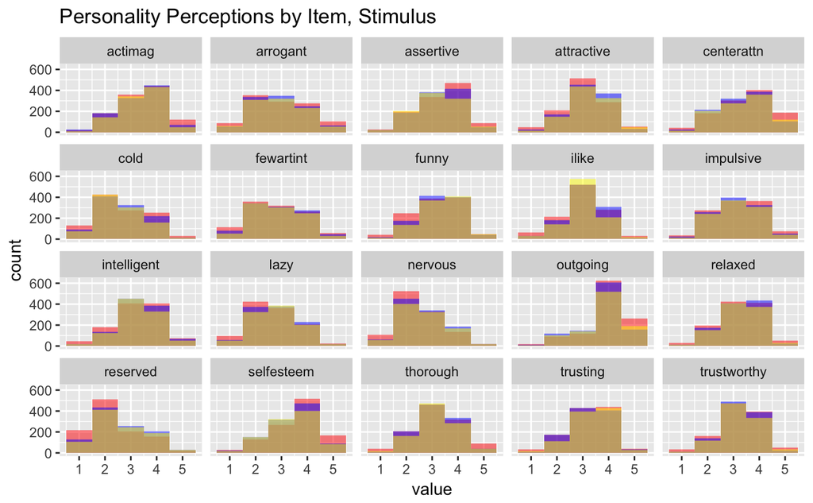

```r
s1q_lab <-c('outgoing','cold','thorough','nervous','actimag','reserved',
            'trusting','lazy','relaxed','fewartint','trustworthy','selfesteem',
            'funny','assertive','arrogant','intelligent','impulsive',
            'centerattn', 'attractive','ilike')
ggplot(df2 %>% filter(qlabel %in% s1q_lab), aes(value)) + facet_wrap(~qlabel) +
        geom_histogram(data = df %>% filter(qlabel %in% s1q_lab & stim =='profile'),
                       fill = 'red', alpha = .5, bins = 5) +
        geom_histogram(data = df %>% filter(qlabel %in% s1q_lab & stim =='friends'),
                       fill = 'blue', alpha = .5, bins = 5) +
        geom_histogram(data = df %>% filter(qlabel %in% s1q_lab & stim =='followers'),
                       fill = 'yellow', alpha = .5, bins = 5) +
        ggtitle('Personality Perceptions by Item, Stimulus')
```

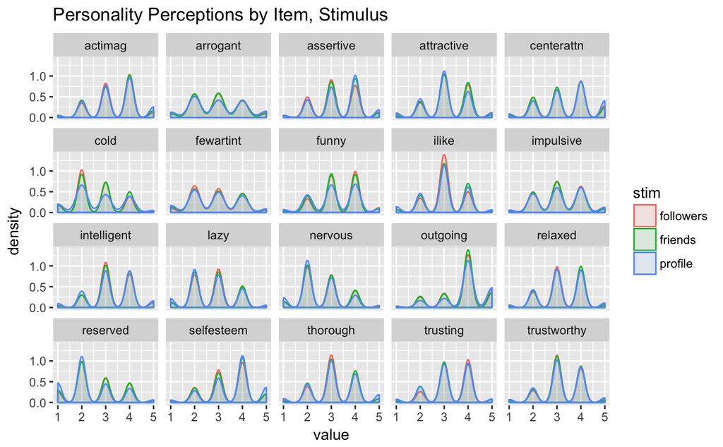

```r
ggplot(df %>% filter(qlabel %in% s1q_lab), aes(value, colour = stim, fill = stim)) +
        facet_wrap(~qlabel) +
        geom_density(alpha = .1)+
        ggtitle('Personality Perceptions by Item, Stimulus')
```

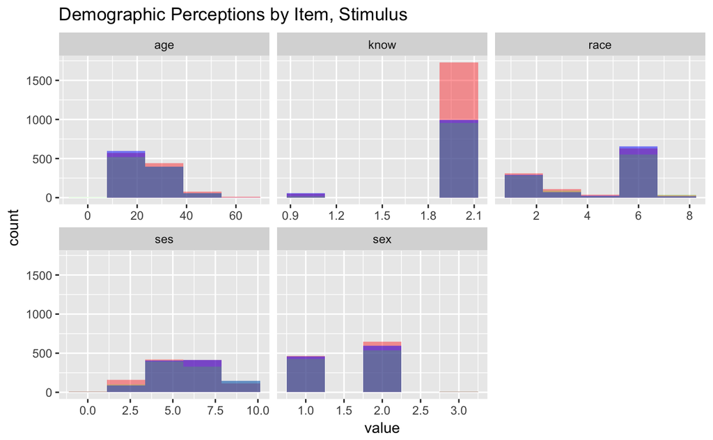

```r
s1q_targdemo <- c('age', 'sex', 'ses','race','know')
ggplot(df %>% filter(qlabel %in% s1q_targdemo), aes(value)) +
        facet_wrap(~qlabel, scales = 'free_x') +
        geom_histogram(data = df %>% filter(qlabel %in% s1q_targdemo & stim =='profile'),
                       fill = 'red', alpha = .4, bins = 5) +
        geom_histogram(data = df %>% filter(qlabel %in% s1q_targdemo & stim =='friends'),
                       fill = 'blue', alpha = .5, bins = 5) +
        geom_histogram(data = df %>% filter(qlabel %in% s1q_targdemo & stim =='followers'),
                       fill = 'green', alpha = .2, bins = 5) +
        ggtitle('Demographic Perceptions by Item, Stimulus')
```

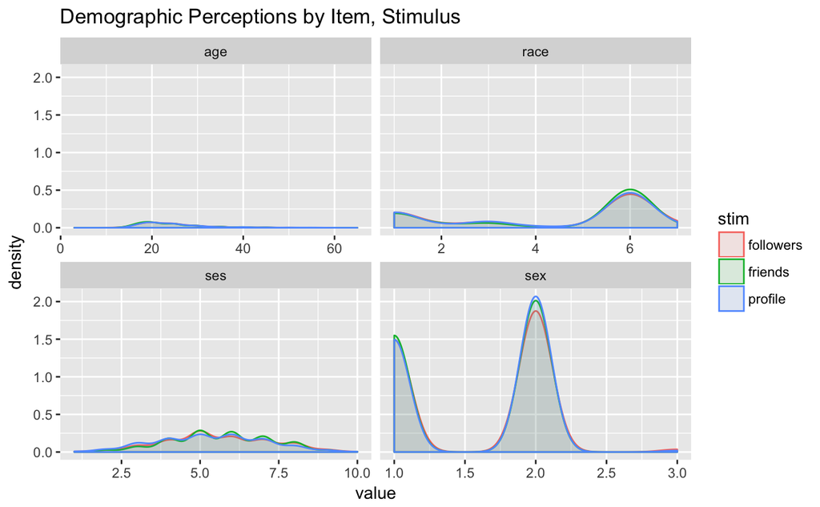

```r
s1q_targdemo2 <- c('age', 'sex', 'ses','race')
ggplot(df %>% filter(qlabel %in% s1q_targdemo2), aes(value, colour = stim, fill = stim)) +
        facet_wrap(~qlabel, scales = 'free_x') +
        geom_density(alpha = .1) +
        ggtitle('Demographic Perceptions by Item, Stimulus')
```

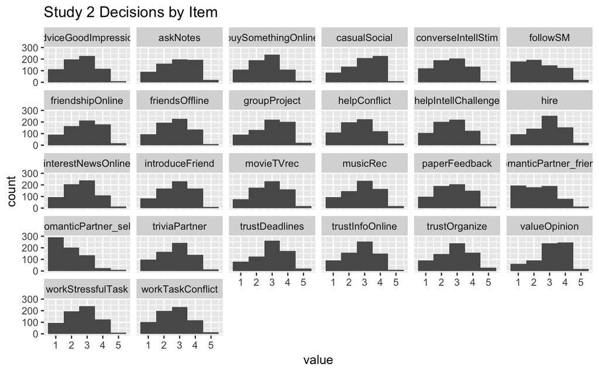

```r
s2q_lab <- c('trustOrganize','followSM','helpConflict','hire', 'friendshipOnline',
             'helpIntellChallenge','movieTVrec','introduceFriend','adviceGoodImpression',
             'romanticPartner_self','triviaPartner','casualSocial','trustInfoOnline',
             'groupProject','buySomethingOnline','interestNewsOnline','askNotes',
             'romanticPartner_friend','converseIntellStim','workTaskConflict',
             'valueOpinion','trustDeadlines','friendsOffline','workStressfulTask',
             'musicRec','paperFeedback')
ggplot(df %>% filter(qlabel %in% s2q_lab), aes(value)) + facet_wrap(~qlabel) +
        geom_histogram(bins = 5) +
        ggtitle('Study 2 Decisions by Item')
```

# ICCs

This will generate ICCs for all of the perception variables, with no additional filtering.

```r
skip <- c('sub_age','sub_durationEng','sub_EngFirstLang', 'sub_raceAsian',
          'sub_raceBlk','sub_raceHisp','sub_raceNatAm','sub_raceOther',
          'sub_raceWht','sub_SES','sub_sex','sub_sexOrientation',
          'sub_socMediaUse','sub_twitteruse')
ICCs<-df2 %>% filter(!(qlabel %in% skip)) %>%
        group_by(study, stim, qlabel) %>%
        do({
                model<-lmer(value~1 + (1|pID) + (1|target_user), data=.)
                var<-as.data.frame(VarCorr(model))
                ICC.p<-round((var[which(var$grp=="pID"),4]/sum(var[,4])),
                             digits = 3)
                ICC.t<-round((var[which(var$grp=="target_user"),4]/sum(var[,4])),
                             digits = 3)
                data.frame(ICC.t,ICC.p)
        })
```

```
|===========================================================================|100% ~0 s remaining
```

Filter out cases where the participant said they knew the target.

```r
ICCs_unknown<- df2a  %>%
        group_by(study, stim, qlabel) %>%
        do({
                model<-lmer(value~1 + (1|pID) + (1|target_user), data=.)
                var<-as.data.frame(VarCorr(model))
                ICC.p_unknown<-round((var[which(var$grp=="pID"),4]/sum(var[,4])),
                             digits = 3)
                ICC.t_unknown<-round((var[which(var$grp=="target_user"),4]/sum(var[,4])),
                             digits = 3)
                data.frame(ICC.t_unknown,ICC.p_unknown)
        })
```

```
|===========================================================================|100% ~0 s remaining
```

```r
iccs <- merge(ICCs,ICCs_unknown, on = c('study','stim','qlabel'))
```

Filter out all subsequent attempts (take just the first attempt overall, instead of just the 1st attempt for a particular stimulus).

```r
df2b <- df2 %>% filter(attempt==1) %>%
        filter(!(qlabel %in% skip))
ICCs_1st<- df2b %>%
        group_by(study, stim, qlabel) %>%
        do({
                model<-lmer(value~1 + (1|pID) + (1|target_user), data=.)
                var<-as.data.frame(VarCorr(model))
                ICC.p_1st<-round((var[which(var$grp=="pID"),4]/sum(var[,4])),
                             digits = 3)
                ICC.t_1st<-round((var[which(var$grp=="target_user"),4]/sum(var[,4])),
                             digits = 3)
                data.frame(ICC.t_1st,ICC.p_1st)
        })
```

```
|======================================================================================|100% ~0 s remaining
```

```r
iccs <- merge(iccs, ICCs_1st, on = c('study','stim','qlabel'))
```

Filter out all subsequent attempts AND knowns.

```r
df2c <- df2 %>% filter(know == 2 & attempt == 1) %>%
        filter(!(qlabel %in% skip))
ICCs_1stunknown<-df2c  %>%
        group_by(study, stim, qlabel) %>%
        do({
                model<-lmer(value~1 + (1|pID) + (1|target_user), data=.)
                var<-as.data.frame(VarCorr(model))
                ICC.p_1stunknown<-round((var[which(var$grp=="pID"),4]/sum(var[,4])),
                             digits = 3)
                ICC.t_1stunknown<-round((var[which(var$grp=="target_user"),4]/sum(var[,4])),
                             digits = 3)
                data.frame(ICC.t_1stunknown,ICC.p_1stunknown)
        })
```

```
|======================================================================================|100% ~0 s remaining
```

```r
iccs <- merge(iccs, ICCs_1stunknown, on = c('study','stim','qlabel'))
head(iccs)
```

|  | study | stim | qlabel | ICC.t_1st | ICC.p_1st | ICC.t | ICC.p | ICC.t_unknown | ICC.p_unknown | ICC.t_1stunknown | ICC.p_1stunknown |
| --- | --- | --- | --- | --- | --- | --- | --- | --- | --- | --- | --- |
| 1 | 1 | followers | actimag | 0.076 | 0.130 | 0.050 | 0.134 | 0.050 | 0.136 | 0.076 | 0.133 |
| 2 | 1 | followers | age | 0.498 | 0.095 | 0.475 | 0.104 | 0.476 | 0.102 | 0.499 | 0.093 |
| 3 | 1 | followers | agr | 0.109 | 0.095 | 0.094 | 0.141 | 0.102 | 0.136 | 0.121 | 0.090 |
| 4 | 1 | followers | arrogant | 0.185 | 0.125 | 0.162 | 0.162 | 0.164 | 0.162 | 0.193 | 0.125 |
| 5 | 1 | followers | assertive | 0.097 | 0.076 | 0.088 | 0.088 | 0.091 | 0.089 | 0.102 | 0.077 |
| 6 | 1 | followers | attractive | 0.155 | 0.129 | 0.133 | 0.144 | 0.134 | 0.145 | 0.156 | 0.129 |

### test differences in iccs based on exclusions

```r
icc_long <- iccs %>%
        gather(key_t, value_t, c(ICC.t, ICC.t_unknown, ICC.t_1st, ICC.t_1stunknown)) %>%
        gather(key_p, value_p, c(ICC.p, ICC.p_unknown, ICC.p_1st, ICC.p_1stunknown))
summary(lm(value_t ~ as.factor(key_t),
           data = (icc_long %>%
                           filter(stim == 'profile' & study == 1))))
```

```
Call:
lm(formula = value_t ~ as.factor(key_t), data = (icc_long %>%
    filter(stim == "profile" & study == 1)))

Residuals:
     Min       1Q   Median       3Q      Max
-0.15591 -0.08491 -0.03791 -0.00291  0.60009

Coefficients:
                                  Estimate Std. Error t value Pr(>|t|)
(Intercept)                      2.329e-01  1.460e-02  15.955   <2e-16 ***
as.factor(key_t)ICC.t_1st        1.197e-16  2.064e-02   0.000    1.000
as.factor(key_t)ICC.t_1stunknown 3.000e-03  2.064e-02   0.145    0.885
as.factor(key_t)ICC.t_unknown    3.000e-03  2.064e-02   0.145    0.885
---
Signif. codes:  0 ‘***’ 0.001 ‘**’ 0.01 ‘*’ 0.05 ‘.’ 0.1 ‘ ’ 1

Residual standard error: 0.1702 on 540 degrees of freedom
Multiple R-squared:  7.82e-05,  Adjusted R-squared:  -0.005477
F-statistic: 0.01408 on 3 and 540 DF,  p-value: 0.9977
```

```r
summary(lm(value_t ~ as.factor(key_t),
           data = (icc_long %>%
                           filter(stim == 'profile' & study == 2))))
```

```
Call:
lm(formula = value_t ~ as.factor(key_t), data = (icc_long %>%
    filter(stim == "profile" & study == 2)))

Residuals:
      Min        1Q    Median        3Q       Max
-0.145808 -0.038308 -0.006808  0.057933  0.153192

Coefficients:
                                   Estimate Std. Error t value Pr(>|t|)
(Intercept)                       2.068e-01  7.215e-03  28.667   <2e-16 ***
as.factor(key_t)ICC.t_1st        -2.573e-17  1.020e-02   0.000    1.000
as.factor(key_t)ICC.t_1stunknown  4.962e-03  1.020e-02   0.486    0.627
as.factor(key_t)ICC.t_unknown     4.962e-03  1.020e-02   0.486    0.627
---
Signif. codes:  0 ‘***’ 0.001 ‘**’ 0.01 ‘*’ 0.05 ‘.’ 0.1 ‘ ’ 1

Residual standard error: 0.07358 on 412 degrees of freedom
Multiple R-squared:  0.001146,  Adjusted R-squared:  -0.006127
F-statistic: 0.1576 on 3 and 412 DF,  p-value: 0.9248
```

```r
summary(lm(value_p ~ as.factor(key_p),
           data = (icc_long %>%
                           filter(stim == 'profile' & study == 1))))
```

```
Call:
lm(formula = value_p ~ as.factor(key_p), data = (icc_long %>%
    filter(stim == "profile" & study == 1)))

Residuals:
     Min       1Q   Median       3Q      Max
-0.11306 -0.02279 -0.01193  0.03394  0.12394

Coefficients:
                                   Estimate Std. Error t value Pr(>|t|)
(Intercept)                       1.168e-01  4.216e-03  27.706   <2e-16 ***
as.factor(key_p)ICC.p_1st        -7.197e-17  5.962e-03   0.000    1.000
as.factor(key_p)ICC.p_1stunknown  3.265e-03  5.962e-03   0.548    0.584
as.factor(key_p)ICC.p_unknown     3.265e-03  5.962e-03   0.548    0.584
---
Signif. codes:  0 ‘***’ 0.001 ‘**’ 0.01 ‘*’ 0.05 ‘.’ 0.1 ‘ ’ 1

Residual standard error: 0.04916 on 540 degrees of freedom
Multiple R-squared:  0.001109,  Adjusted R-squared:  -0.00444
F-statistic: 0.1999 on 3 and 540 DF,  p-value: 0.8964
```

```r
summary(lm(value_p ~ as.factor(key_p),
           data = (icc_long %>%
                           filter(stim == 'profile' & study == 2))))
```

```
Call:
lm(formula = value_p ~ as.factor(key_p), data = (icc_long %>%
    filter(stim == "profile" & study == 2)))

Residuals:
     Min       1Q   Median       3Q      Max
-0.08885 -0.05239 -0.01223  0.03790  0.19115

Coefficients:
                                   Estimate Std. Error t value Pr(>|t|)
(Intercept)                       1.698e-01  6.068e-03  27.992   <2e-16 ***
as.factor(key_p)ICC.p_1st        -2.121e-17  8.581e-03   0.000    1.000
as.factor(key_p)ICC.p_1stunknown -5.615e-03  8.581e-03  -0.654    0.513
as.factor(key_p)ICC.p_unknown    -5.615e-03  8.581e-03  -0.654    0.513
---
Signif. codes:  0 ‘***’ 0.001 ‘**’ 0.01 ‘*’ 0.05 ‘.’ 0.1 ‘ ’ 1

Residual standard error: 0.06188 on 412 degrees of freedom
Multiple R-squared:  0.002074,  Adjusted R-squared:  -0.005192
F-statistic: 0.2855 on 3 and 412 DF,  p-value: 0.8359
```

```r
summary(lm(value_t ~ as.factor(key_t),
           data = (icc_long %>%
                           filter(stim == 'followers'))))
```

```
Call:
lm(formula = value_t ~ as.factor(key_t), data = (icc_long %>%
    filter(stim == "followers")))

Residuals:
     Min       1Q   Median       3Q      Max
-0.13465 -0.07115 -0.02534  0.02499  0.52885

Coefficients:
                                 Estimate Std. Error t value Pr(>|t|)
(Intercept)                      0.125794   0.010635  11.828   <2e-16 ***
as.factor(key_t)ICC.t_1st        0.007353   0.015041   0.489    0.625
as.factor(key_t)ICC.t_1stunknown 0.009853   0.015041   0.655    0.513
as.factor(key_t)ICC.t_unknown    0.001735   0.015041   0.115    0.908
---
Signif. codes:  0 ‘***’ 0.001 ‘**’ 0.01 ‘*’ 0.05 ‘.’ 0.1 ‘ ’ 1

Residual standard error: 0.124 on 540 degrees of freedom
Multiple R-squared:  0.001054,  Adjusted R-squared:  -0.004495
F-statistic:  0.19 on 3 and 540 DF,  p-value: 0.9032
```

```r
### this one makes a difference:
summary(lm(value_p ~ as.factor(key_p),
           data = (icc_long %>%
                           filter(stim == 'followers'))))
```

```
Call:
lm(formula = value_p ~ as.factor(key_p), data = (icc_long %>%
    filter(stim == "followers")))

Residuals:
      Min        1Q    Median        3Q       Max
-0.144735 -0.028721  0.000618  0.031441  0.132971

Coefficients:
                                   Estimate Std. Error t value Pr(>|t|)
(Intercept)                       1.498e-01  4.943e-03  30.313   <2e-16 ***
as.factor(key_p)ICC.p_1st        -1.979e-02  6.990e-03  -2.832   0.0048 **
as.factor(key_p)ICC.p_1stunknown -2.021e-02  6.990e-03  -2.891   0.0040 **
as.factor(key_p)ICC.p_unknown    -8.824e-05  6.990e-03  -0.013   0.9899
---
Signif. codes:  0 ‘***’ 0.001 ‘**’ 0.01 ‘*’ 0.05 ‘.’ 0.1 ‘ ’ 1

Residual standard error: 0.05764 on 540 degrees of freedom
Multiple R-squared:  0.02931,   Adjusted R-squared:  0.02392
F-statistic: 5.435 on 3 and 540 DF,  p-value: 0.001092
```

```r
summary(lm(value_t ~ as.factor(key_t),
           data = (icc_long %>%
                           filter(stim == 'friends'))))
```

```
Call:
lm(formula = value_t ~ as.factor(key_t), data = (icc_long %>%
    filter(stim == "friends")))

Residuals:
     Min       1Q   Median       3Q      Max
-0.13206 -0.07421 -0.01560  0.04043  0.52171

Coefficients:
                                 Estimate Std. Error t value Pr(>|t|)
(Intercept)                      0.149824   0.010003  14.978   <2e-16 ***
as.factor(key_t)ICC.t_1st        0.004559   0.014146   0.322    0.747
as.factor(key_t)ICC.t_1stunknown 0.006235   0.014146   0.441    0.660
as.factor(key_t)ICC.t_unknown    0.001471   0.014146   0.104    0.917
---
Signif. codes:  0 ‘***’ 0.001 ‘**’ 0.01 ‘*’ 0.05 ‘.’ 0.1 ‘ ’ 1

Residual standard error: 0.1167 on 540 degrees of freedom
Multiple R-squared:  0.000448,  Adjusted R-squared:  -0.005105
F-statistic: 0.08068 on 3 and 540 DF,  p-value: 0.9705
```

```r
summary(lm(value_p ~ as.factor(key_p),
           data = (icc_long %>%
                           filter(stim == 'friends'))))
```

```
Call:
lm(formula = value_p ~ as.factor(key_p), data = (icc_long %>%
    filter(stim == "friends")))

Residuals:
     Min       1Q   Median       3Q      Max
-0.13359 -0.03115 -0.00250  0.02032  0.21085

Coefficients:
                                  Estimate Std. Error t value Pr(>|t|)
(Intercept)                       0.129500   0.004837  26.772   <2e-16 ***
as.factor(key_p)ICC.p_1st        -0.010647   0.006841  -1.556    0.120
as.factor(key_p)ICC.p_1stunknown -0.007353   0.006841  -1.075    0.283
as.factor(key_p)ICC.p_unknown     0.004088   0.006841   0.598    0.550
---
Signif. codes:  0 ‘***’ 0.001 ‘**’ 0.01 ‘*’ 0.05 ‘.’ 0.1 ‘ ’ 1

Residual standard error: 0.05641 on 540 degrees of freedom
Multiple R-squared:  0.01063,   Adjusted R-squared:  0.005134
F-statistic: 1.934 on 3 and 540 DF,  p-value: 0.123
```

Look at correlations among iccs?

Over everything (not especially meaningful, probably):

```r
cor(iccs[c(4,6,8,10,5,7,9,11)])
```

```
                  ICC.t_1st      ICC.t ICC.t_unknown ICC.t_1stunknown  ICC.p_1st      ICC.p ICC.p_unknown
ICC.t_1st         1.0000000  0.9977521     0.9966622        0.9991687 -0.4068609 -0.4490274    -0.4669222
ICC.t             0.9977521  1.0000000     0.9992985        0.9973793 -0.4128722 -0.4595603    -0.4793737
ICC.t_unknown     0.9966622  0.9992985     1.0000000        0.9977413 -0.4140248 -0.4604907    -0.4805816
ICC.t_1stunknown  0.9991687  0.9973793     0.9977413        1.0000000 -0.4094229 -0.4511499    -0.4693612
ICC.p_1st        -0.4068609 -0.4128722    -0.4140248       -0.4094229  1.0000000  0.9756556     0.9658850
ICC.p            -0.4490274 -0.4595603    -0.4604907       -0.4511499  0.9756556  1.0000000     0.9902674
ICC.p_unknown    -0.4669222 -0.4793737    -0.4805816       -0.4693612  0.9658850  0.9902674     1.0000000
ICC.p_1stunknown -0.4210301 -0.4286074    -0.4299084       -0.4237566  0.9892438  0.9616054     0.9719413
                 ICC.p_1stunknown
ICC.t_1st              -0.4210301
ICC.t                  -0.4286074
ICC.t_unknown          -0.4299084
ICC.t_1stunknown       -0.4237566
ICC.p_1st               0.9892438
ICC.p                   0.9616054
ICC.p_unknown           0.9719413
ICC.p_1stunknown        1.0000000
```

By study/stimuli:

```r
iccs %>% group_by(study, stim) %>%
        do({
                data.frame(cor(iccs[c(4,6,8,10,5,7,9,11)]))
                })
```

| study | stim | ICC.t_1st | ICC.t | ICC.t_unknown | ICC.t_1stunknown | ICC.p_1st | ICC.p | ICC.p_unknown | ICC.p_1stunknown |
| --- | --- | --- | --- | --- | --- | --- | --- | --- | --- |
| 1 | followers | 1.0000000 | 0.9977521 | 0.9966622 | 0.9991687 | -0.4068609 | -0.4490274 | -0.4669222 | -0.4210301 |
| 1 | followers | 0.9977521 | 1.0000000 | 0.9992985 | 0.9973793 | -0.4128722 | -0.4595603 | -0.4793737 | -0.4286074 |
| 1 | followers | 0.9966622 | 0.9992985 | 1.0000000 | 0.9977413 | -0.4140248 | -0.4604907 | -0.4805816 | -0.4299084 |
| 1 | followers | 0.9991687 | 0.9973793 | 0.9977413 | 1.0000000 | -0.4094229 | -0.4511499 | -0.4693612 | -0.4237566 |
| 1 | followers | -0.4068609 | -0.4128722 | -0.4140248 | -0.4094229 | 1.0000000 | 0.9756556 | 0.9658850 | 0.9892438 |
| 1 | followers | -0.4490274 | -0.4595603 | -0.4604907 | -0.4511499 | 0.9756556 | 1.0000000 | 0.9902674 | 0.9616054 |
| 1 | followers | -0.4669222 | -0.4793737 | -0.4805816 | -0.4693612 | 0.9658850 | 0.9902674 | 1.0000000 | 0.9719413 |
| 1 | followers | -0.4210301 | -0.4286074 | -0.4299084 | -0.4237566 | 0.9892438 | 0.9616054 | 0.9719413 | 1.0000000 |
| 1 | friends | 1.0000000 | 0.9977521 | 0.9966622 | 0.9991687 | -0.4068609 | -0.4490274 | -0.4669222 | -0.4210301 |
| 1 | friends | 0.9977521 | 1.0000000 | 0.9992985 | 0.9973793 | -0.4128722 | -0.4595603 | -0.4793737 | -0.4286074 |

[output cut: 22 more lines]

Calculate differences, to see how big the changes are.

```r
psych::describe(iccs %>% filter(study == 2))[1:4]
```

[output not shown]

```
                         vars  n mean   sd
study                       1 26 2.00 0.00
stim*                       2 26  NaN   NA
qlabel*                     3 26  NaN   NA
ICC.t_1st                   4 26 0.21 0.07
ICC.p_1st                   5 26 0.17 0.06
ICC.t                       6 26 0.21 0.07
ICC.p                       7 26 0.17 0.06
ICC.t_unknown               8 26 0.21 0.08
ICC.p_unknown               9 26 0.16 0.06
ICC.t_1stunknown           10 26 0.21 0.08
ICC.p_1stunknown           11 26 0.16 0.06
diff_allunknown.t          12 26 0.00 0.01
diff_all1st.t              13 26 0.00 0.00
diff_allunknown1st.t       14 26 0.00 0.01
diff_1stunknown.t          15 26 0.00 0.01
diff_1stunknown1st.t       16 26 0.00 0.01
diff_unknown1stunknown.t   17 26 0.00 0.00
diff_allunknown.p          18 26 0.01 0.01
diff_all1st.p              19 26 0.00 0.00
diff_allunknown1st.p       20 26 0.01 0.01
diff_1stunknown.p          21 26 0.01 0.01
diff_1stunknown1st.p       22 26 0.01 0.01
diff_unknown1stunknown.p   23 26 0.00 0.00
```

The differences are generally very small, and all of the filters produce similar results. I’m inclined to retain as much of the data as possible, and so will proceed with the relatively un-filtered dataset, with ‘knowns’ removed. This one has removed all but the first attempt from each participant for each stimuli, and has removed subsequent responses from participants who saw stimuli for the same set of targets, but retains participants (all from MTurk) who rated different sets of targets across different kinds of stimuli.

I’m seeing here that whether or not a participant indicated that they knew a target doesn’t dramatically impact the ratings of the targets. However, we are concerned with how people rate strangers on the internet. Although the answers to this question are rather ambiguous for friends/followers (e.g., the participant may have known someone in the collage, or may be familiar with, e.g., a celebrity in the collage rather than actually know who the target is), I’ll remove these to keep the data consistent with itself. It’s also important to keep in mind that, because these targets were chosen at random, it’s possible that participants who inidcated they knew a target may just have not been paying attention. Participants answered this question for each target they saw. I will retain their responses for targets they said they did *not* know, and just remove those who they said they knew.

```r
df2a1 <- df2 %>% filter(know == 2)
write.csv(df2a1, 'Personality_Impressions_on_Twitter_Filtered_noKnowns_091717.csv')
#save the ICCs
write.csv(ICCs_unknown, 'Personality_Impressions_on_Twitter_ICCs_091717.csv')
```

### Descriptives, again

Re-run the descriptives without the known targets included. *These should be what wind up in the paper.*

Study 1:

```r
s1p <- suppressWarnings(data.frame(psych::describe(df_wide %>%
                                                    filter(study == 1 & know == 'no'
                                                           & stim == 'profile'))[19:93,1:4]))
s1p <- s1p %>% mutate(vars = rownames(s1p)) %>% filter(n > 0) %>%
        rename(N_profile = n, M_profile = mean, SD_profile = sd)
s1fo <- suppressWarnings(data.frame(psych::describe(df_wide %>%
                                                     filter(study == 1 & know == 'no'
                                                            & stim == 'followers'))[19:93,1:4]))
s1fo <- s1fo %>% mutate(vars = rownames(s1fo)) %>% filter(n > 0)%>%
        rename(N_followers = n, M_followers = mean, SD_followers = sd)
s1f <- suppressWarnings(data.frame(psych::describe(df_wide %>%
                                                    filter(study == 1 & know == 'no'
                                                           & stim == 'friends'))[19:93,1:4]))
s1f <- s1f %>% mutate(vars = rownames(s1f)) %>% filter(n > 0)%>%
        rename(N_friends = n, M_friends = mean, SD_friends = sd)
merge(s1p,s1f, by = 'vars') %>% merge(s1fo, by = 'vars')
```

| vars | N_profile | M_profile | SD_profile | N_friends | M_friends | SD_friends | N_followers | M_followers | SD_followers |
| --- | --- | --- | --- | --- | --- | --- | --- | --- | --- |
| actimag | 1098 | 3.409836 | 0.9430327 | 995 | 3.330653 | 0.9226717 | 954 | 3.370021 | 0.8437055 |
| age | 1091 | 25.151237 | 8.2261636 | 995 | 24.116583 | 7.3238177 | 953 | 24.321091 | 7.2394335 |
| agr | 1096 | 3.451186 | 0.6208982 | 995 | 3.345226 | 0.6658264 | 954 | 3.377883 | 0.6318939 |
| arrogant | 1096 | 2.962591 | 1.1256520 | 995 | 2.925628 | 1.0042648 | 954 | 2.899371 | 1.0038434 |
| assertive | 1098 | 3.349727 | 0.9324031 | 994 | 3.256539 | 0.8894495 | 954 | 3.183438 | 0.9028917 |
| attractive | 1096 | 3.073905 | 0.9010464 | 995 | 3.178894 | 0.8296303 | 954 | 3.256813 | 0.8259185 |
| centerattn | 1098 | 3.455373 | 1.0633161 | 995 | 3.304523 | 0.9922890 | 954 | 3.365828 | 1.0022671 |
| cold | 1096 | 2.677007 | 1.0432040 | 995 | 2.678392 | 0.9468179 | 954 | 2.597484 | 0.8985437 |
| cold_r | 1096 | 3.322993 | 1.0432040 | 995 | 3.321608 | 0.9468179 | 954 | 3.402516 | 0.8985437 |
| con | 1098 | 3.249089 | 0.8299455 | 995 | 3.191457 | 0.7524456 | 954 | 3.180818 | 0.7323000 |

[output cut: 25 more lines]

Study 2:

```r
s2p <- suppressWarnings(data.frame(psych::describe(df_wide %>%
                                                    filter(study == 2 & know == 'no'))[19:93,1:4]))
s2p %>% mutate(vars = rownames(s2p)) %>% filter(n > 0)
```

| vars | n | mean | sd |
| --- | --- | --- | --- |
| adviceGoodImpression | 623 | 2.528090 | 0.9961812 |
| askNotes | 627 | 2.835726 | 1.0858366 |
| buySomethingOnline | 625 | 2.552000 | 0.9988455 |
| casualSocial | 626 | 2.889776 | 1.0456727 |
| converseIntellStim | 627 | 2.559809 | 1.0517802 |
| followSM | 627 | 2.358852 | 1.1264028 |
| friendshipOnline | 627 | 2.757576 | 1.0522694 |
| friendsOffline | 627 | 2.622010 | 1.0011306 |
| groupProject | 626 | 2.864217 | 1.0609117 |
| helpConflict | 628 | 2.579618 | 1.0189740 |

[output cut: 17 more lines]

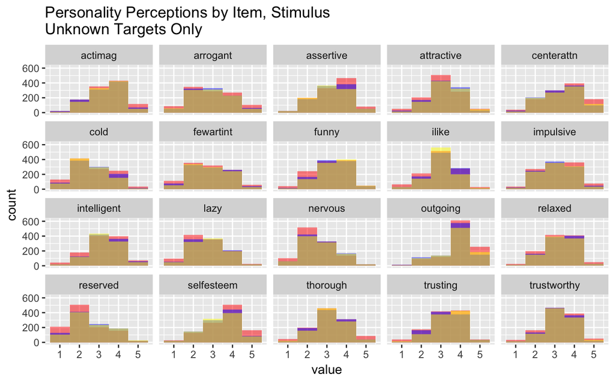

```r
s1q_lab <-c('outgoing','cold','thorough','nervous','actimag','reserved',
            'trusting','lazy','relaxed','fewartint','trustworthy','selfesteem',
            'funny','assertive','arrogant','intelligent','impulsive',
            'centerattn', 'attractive','ilike')
ggplot(df2 %>% filter(qlabel %in% s1q_lab & know == 2), aes(value)) + facet_wrap(~qlabel) +
        geom_histogram(data = df2 %>% filter(qlabel %in% s1q_lab & stim =='profile' & know == 2),
                       fill = 'red', alpha = .5, bins = 5) +
        geom_histogram(data = df2 %>% filter(qlabel %in% s1q_lab & stim =='friends' & know == 2),
                       fill = 'blue', alpha = .5, bins = 5) +
        geom_histogram(data = df2 %>% filter(qlabel %in% s1q_lab & stim =='followers' & know == 2),
                       fill = 'yellow', alpha = .5, bins = 5) +
        ggtitle('Personality Perceptions by Item, Stimulus\nUnknown Targets Only')
```

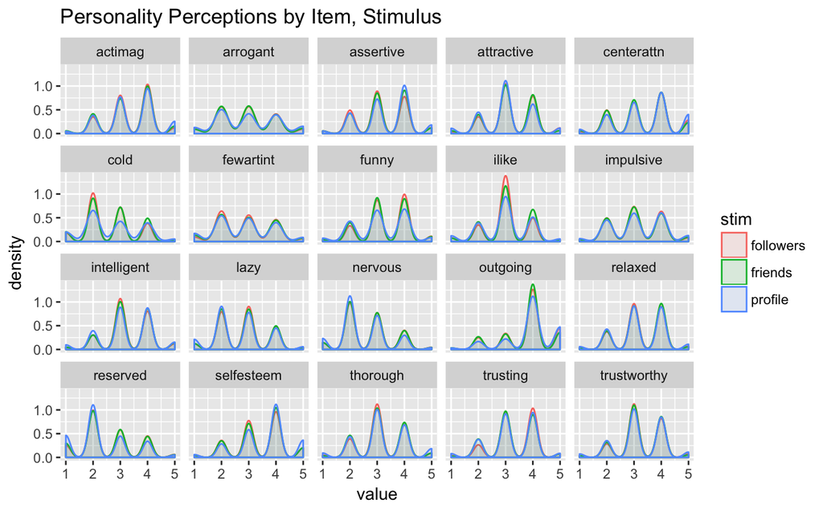

```r
ggplot(df2 %>% filter(qlabel %in% s1q_lab & know == 2), aes(value, colour = stim, fill = stim)) +
        facet_wrap(~qlabel) +
        geom_density(alpha = .1)+
        ggtitle('Personality Perceptions by Item, Stimulus')
```

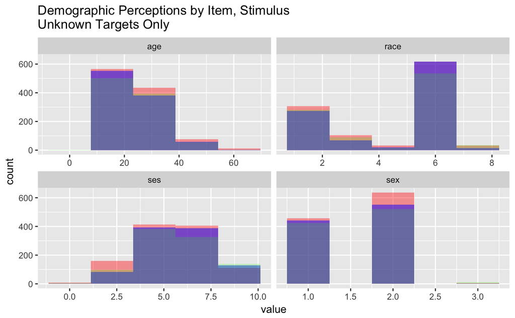

```r
s1q_targdemo <- c('age', 'sex', 'ses','race','know')
ggplot(df2 %>% filter(qlabel %in% s1q_targdemo & know == 2), aes(value)) +
        facet_wrap(~qlabel, scales = 'free_x') +
        geom_histogram(data = df2 %>% filter(qlabel %in% s1q_targdemo & stim =='profile' & know == 2),
                       fill = 'red', alpha = .4, bins = 5) +
        geom_histogram(data = df2 %>% filter(qlabel %in% s1q_targdemo & stim =='friends' & know == 2),
                       fill = 'blue', alpha = .5, bins = 5) +
        geom_histogram(data = df2 %>% filter(qlabel %in% s1q_targdemo & stim =='followers' & know == 2),
                       fill = 'green', alpha = .2, bins = 5) +
        ggtitle('Demographic Perceptions by Item, Stimulus\nUnknown Targets Only')
```

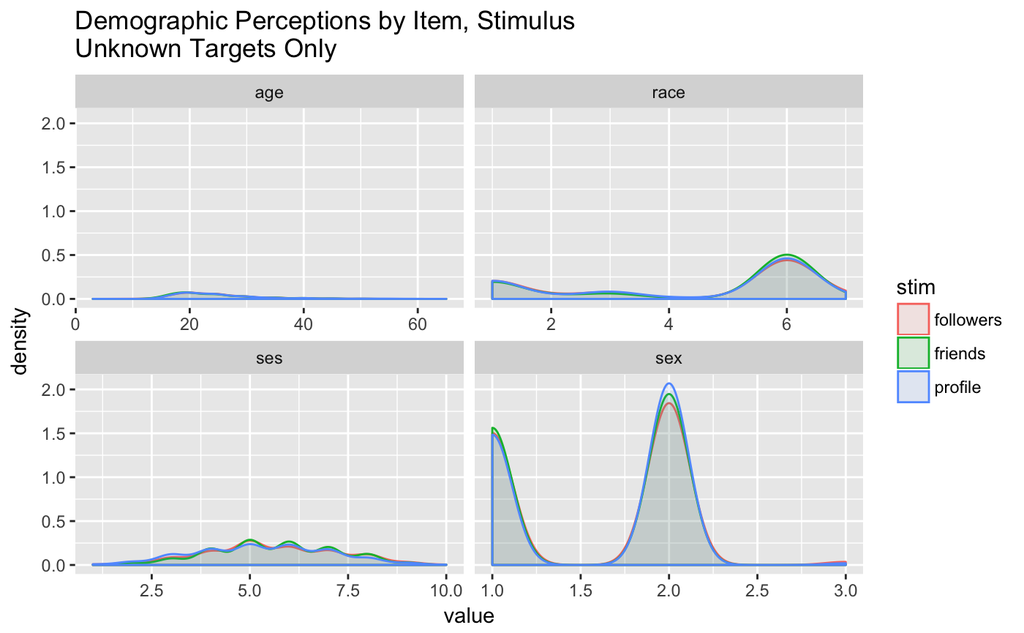

```r
s1q_targdemo2 <- c('age', 'sex', 'ses','race')
ggplot(df2 %>% filter(qlabel %in% s1q_targdemo2 & know == 2), aes(value, colour = stim, fill = stim)) +
        facet_wrap(~qlabel, scales = 'free_x') +
        geom_density(alpha = .1) +
        ggtitle('Demographic Perceptions by Item, Stimulus\nUnknown Targets Only')
```

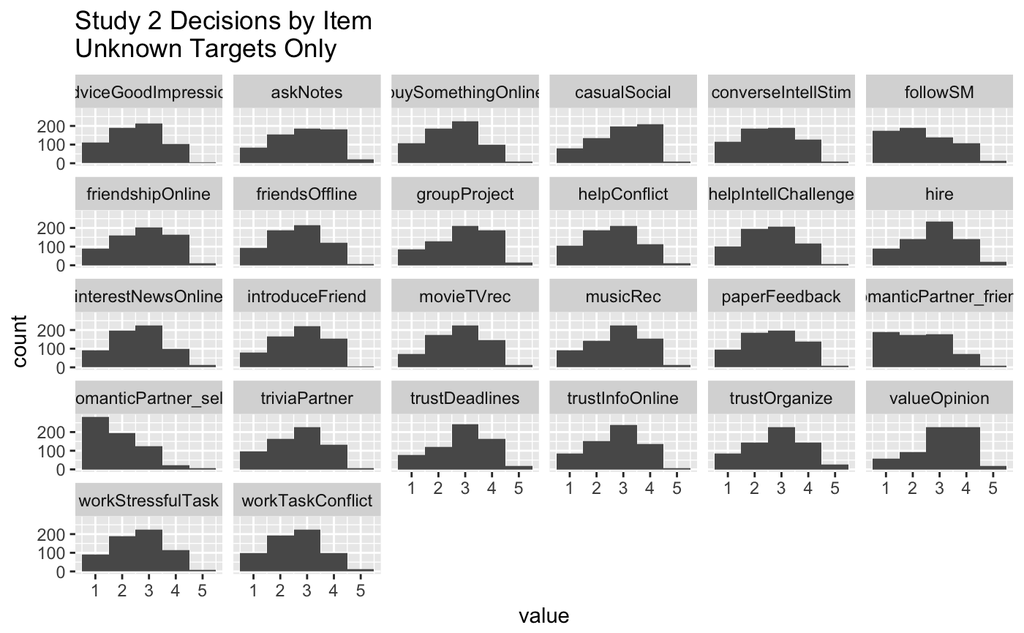

```r
s2q_lab <- c('trustOrganize','followSM','helpConflict','hire', 'friendshipOnline',
             'helpIntellChallenge','movieTVrec','introduceFriend','adviceGoodImpression',
             'romanticPartner_self','triviaPartner','casualSocial','trustInfoOnline',
             'groupProject','buySomethingOnline','interestNewsOnline','askNotes',
             'romanticPartner_friend','converseIntellStim','workTaskConflict',
             'valueOpinion','trustDeadlines','friendsOffline','workStressfulTask',
             'musicRec','paperFeedback')
ggplot(df2 %>% filter(qlabel %in% s2q_lab & know == 2), aes(value)) + facet_wrap(~qlabel) +
        geom_histogram(bins = 5) +
        ggtitle('Study 2 Decisions by Item\nUnknown Targets Only')
```

### Onward and upward

This notebook dealt primiarly with the disaggregated data. Please see the next in the series, *Target-level Aggregation* for next steps in the analysis. There, I’ll roll everything up to the target level, using the known-excluded data from this notebook.